# DASC 500: Introduction to Data Analytics

A Gentle Introduction to Supervised Learning Algorithms

Maj Jason Freels PhD

10 June 2020

# Overview

## In the previous class we introduced…

- Supervised and unsupervised learning algorithms
- The importance of loss functions
  - Convex and non-convex loss functions
  - The Least squares loss function
- Ordinary least squares and simple linear regression
  - Model building
  - Understanding model results and model diagnostics
  - Making predictions

## In this class…

- Extend to multiple linear regression
- Add details to our understanding of model diagnostics
- Other concepts

# Linear Regression

## Overview

# Replication Requirements

## Importing libraries

- First, let’s be sure to import the Python libraries we’ll need to complete this analysis

```python
import random
import numpy as np
import pandas as pd
import seaborn as sb
import matplotlib.pyplot as plt
import scipy as sp
import statsmodels.api as sm
import statistics as st
```

## understanding the data

- This lecture uses the [advertising](http://www-bcf.usc.edu/~gareth/ISL/Advertising.csv) data set made available by the authors of the text [An Introduction to Statistical Learning](http://www-bcf.usc.edu/~gareth/ISL/index.html)
- The data set contains four columns of advertising-related features captured across 200 markets
  - `TV`: Money spent on television advertising (in thousands of dollars)
  - `radio`: Money spent on radio (in thousands of dollars)
  - `newspaper`: Money spent on newspaper advertising (in thousands of dollars)
  - `Sales`: return on the advertising investment (in dollars)
- The question to be addressed by analyzing this data set
  - Is there are relationship between `Sales` and the way that advertising dollars are spent
  - To what degree does money spent on `TV` advertising impact `Sales`
  - To what degree does money spent on `radio` advertising impact `Sales`
  - To what degree does money spent on `newspaper` advertising impact `Sales`
  - What type of advertising provides the greatest impact on `Sales`

## Accessing the data

- To access the data, we’ll extract it from the CSV file and store it as a `pandas` DataFrame using `read_csv()`
  - Assign the URL to a text string
  - Assing the extracted data to a DataFrame called `df`

```python
data_url = "http://faculty.marshall.usc.edu/gareth-james/ISL/Advertising.csv"

df = pd.read_csv(data_url)
```

- Note that extracting the data in this manner results in an un-needed column containing the row numbers

```python
df.head()
```

```
   Unnamed: 0     TV  radio  newspaper  sales
0           1  230.1   37.8       69.2   22.1
1           2   44.5   39.3       45.1   10.4
2           3   17.2   45.9       69.3    9.3
3           4  151.5   41.3       58.5   18.5
4           5  180.8   10.8       58.4   12.9
```

- Instead, use the `usecols` argument to select which columns we want to extract
- Note that we supply these column names as a list using `{ }`

```python
df2 = pd.read_csv(data_url,
                  usecols = {'TV','newspaper','radio','sales'})

df2.head()
```

```
      TV  radio  newspaper  sales
0  230.1   37.8       69.2   22.1
1   44.5   39.3       45.1   10.4
2   17.2   45.9       69.3    9.3
3  151.5   41.3       58.5   18.5
4  180.8   10.8       58.4   12.9
```

# Preparing Our Data

## Partitioning the data

- Initial discovery of relationships is usually done with a training set while a test set is used for evaluating whether the discovered relationships hold
  - A training set is used to discover potentially predictive relationships
  - A test set is used to assess the strength and utility of a predictive relationship.
- We’ll use a 60% / 40% split to partition the data set
  - We train our model on 60% of the data
  - Then test the model performance on the 40% of the data that was withheld

```python
train_data = df2.sample(frac = 0.6)
test_data  = df2.drop(train_data.index)
```

# Multiple linear regression - Overview

- In this lecture we will build three models
  - A simple linear regression model (the model we built last time)
  - A multiple linear regression that includes `TV`, `radio`, and `newspaper` as predictors
  - A multiple linear regression model that includes an interaction term

## Simple linear regression model

- Recall from last time that we built a simple regression model in Python using the `OLS()` (ordinary least squares) function from the `api` module in the `statsmodels` library
- In matrix notation, this model is expressed as

$$\begin{aligned}
\boldsymbol{y} &= \beta_0 + \beta_{1}\boldsymbol{X} + \epsilon\\\\
\begin{bmatrix}
y_{1} \\
y_{2} \\
\vdots \\
y_{m}
\end{bmatrix} &=
\begin{bmatrix}
1& X_{1}\\
1& X_{2}\\
\vdots & \vdots \\
1& X_{m}
\end{bmatrix}
\begin{bmatrix}
\beta_{0} \\
\beta_{1}
\end{bmatrix}+
\begin{bmatrix}
\epsilon_{1} \\
\epsilon_{2} \\
\vdots \\
\epsilon_{m}
\end{bmatrix}
\end{aligned}$$

- where:
  - $y$ is a vector of responses
  - $X$ is a matrix of input values
  - $\beta_0$ is an intercept parameter
  - $\beta_1$ is the effect parameter for $X_1$
  - $\epsilon$ is a mean-zero random error term
- To build this model, we first need to define the $X$-matrix of inputs and the $y$ vector of responses from the training data - this is done below

```python
y  = train_data["sales"]
X1 = train_data[{"TV"}]
```

- Then, we need to add the column of ones to the $X$-matrix to account for the intercept term

```python
X1 = sm.add_constant(X1)
```

- With $X$ and $y$ defined we build the model and fit it to the data

```python
model1 = sm.OLS(y, X1)

model1_fit = model1.fit()
```

## Multiple linear regression model (w/o interaction)

- In this case we wish to model the relationship between the response `sales` and the predictors `TV`, `radio`, and `newspaper`
- In matrix notation, this model is expressed as

$$\begin{aligned}
\boldsymbol{y} &= \beta_0 + \beta_{1}\boldsymbol{X}_1 + \beta_{2}\boldsymbol{X}_2 + \beta_{3}\boldsymbol{X}_3 + \epsilon\\\\
\begin{bmatrix}
y_{1} \\
y_{2} \\
\vdots \\
y_{m}
\end{bmatrix} &=
\begin{bmatrix}
1& X_{11} & X_{21} & X_{31}\\
1& X_{12} & X_{22} & X_{32}\\
\vdots & \vdots & \vdots & \vdots \\
1& X_{1m} & X_{2m} & X_{3m}
\end{bmatrix}
\begin{bmatrix}
\beta_{0} \\
\beta_{1} \\
\beta_{2} \\
\beta_{3}
\end{bmatrix}+
\begin{bmatrix}
\epsilon_{1} \\
\epsilon_{2} \\
\vdots \\
\epsilon_{m}
\end{bmatrix}
\end{aligned}$$

- where:
  - $y_1,\ldots,y_m$ is the vector of responses
  - $X$ is a matrix of input values
  - $\beta_0$ is an intercept parameter
  - $\beta_1$ is the effect parameter for the predictor $X_1$
  - $\beta_2$ is the effect parameter for the predictor $X_2$
  - $\beta_3$ is the effect parameter for the predictor $X_3$
  - $\epsilon$ is a mean-zero random error term
- To build this model, we only need to define a second $X$-matrix of inputs as the $y$ vector of responses is the same

```python
X2 = train_data[{"TV","newspaper","radio"}]
```

- Then, we need to add the column of ones to the $X$-matrix to account for the intercept term

```python
X2 = sm.add_constant(X2)
```

- With $X$ and $y$ defined we build the our multiple regression model called `model2` and fit it to the data

```python
model2 = sm.OLS(y, X2)

model2_fit = model2.fit()
```

## Multiple linear regression model (with an interaction term)

- As we’ll see below `newspaper` is not a statistically significant predictor for the response
- Moreover, we’ll see that there is a multiplicative effect between the predictors `TV` and `radio`
- Therefore, in this case we build a model to reflect these notions
- In matrix notation, this model is expressed as

$$\begin{aligned}
\boldsymbol{y} &= \beta_0 + \beta_{1}\boldsymbol{X}_1 + \beta_{2}\boldsymbol{X}_2 + \beta_{3}\boldsymbol{X}_1\boldsymbol{X}_2 + \epsilon\\\\
\begin{bmatrix}
y_{1} \\
y_{2} \\
\vdots \\
y_{m}
\end{bmatrix} &=
\begin{bmatrix}
1& X_{11} & X_{21} & X_{11}X_{21}\\
1& X_{12} & X_{22} & X_{12}X_{22}\\
\vdots & \vdots & \vdots & \vdots \\
1& X_{1m} & X_{2m} & X_{1m}X_{2m}
\end{bmatrix}
\begin{bmatrix}
\beta_{0} \\
\beta_{1} \\
\beta_{2} \\
\beta_{3}
\end{bmatrix}+
\begin{bmatrix}
\epsilon_{1} \\
\epsilon_{2} \\
\vdots \\
\epsilon_{m}
\end{bmatrix}
\end{aligned}$$

- where:
  - $y_1,\ldots,y_m$ is the vector of responses
  - $X$ is a matrix of input values
  - $\beta_0$ is an intercept parameter
  - $\beta_1$ is the effect parameter for the predictor $X_1$
  - $\beta_2$ is the effect parameter for the predictor $X_2$
  - $\beta_3$ is the effect parameter for the interaction $X_1X_2$
  - $\epsilon$ is a mean-zero random error term
- To build this model, we only need to define a third $X$-matrix of inputs as the $y$ vector of responses is the same

```python
train_data["rt"] = train_data["radio"] * train_data["TV"]
test_data["rt"]  = test_data["radio"] * test_data["TV"]

X3 = train_data[{"TV","radio","rt"}]
```

- Then, we need to add the column of ones to the $X$-matrix to account for the intercept term

```python
X3 = sm.add_constant(X3)
```

```python
model3 = sm.OLS(y, X3)

model3_fit = model3.fit()
```

# Inspecting the model

## Visually and Numerically inspecting the models

- Building a linear regression model is only half of the work
- To use the model you must should check that it conforms to the assumptions of linear regression
  - The model is linear in parameters
  - The mean of the residuals is zero
  - The residuals are normally distributed
- In the following sections we take a look at several numeric and visual summaries for each model
  - Model numeric summaries
  - Residual plots
  - Quantile-quantile plots

# Inspecting Model Parameters

## Overview

- After fitting the model to the data it’s important to know if the these coefficients are statistically significant
  - Can we state that these coefficients are statistically different from 0?
  - To do that we can start by assessing the standard errors (SE) for the parameters $\beta_0$ and $\beta_1$
  - These values are computed as shown below where $\sigma^2 = Var(\epsilon)$

$$\begin{aligned}
SE(\beta_0)^2 &= \sigma^2\bigg[\frac{1}{n}+\frac{\bar{x}^2}{\sum^n_{i=1}(x_i - \bar{x})^2} \bigg]\\\\
SE(\beta_1)^2 &= \frac{\sigma^2}{\sum^n_{i=1}(x_i - \bar{x})^2}
\end{aligned}$$

- The model summary show the 95% confidence interval for $\beta_1$
  - Since zero is not in this interval we can conclude that as the TV advertising budget increases by $1,000 we can expect the sales to increase
  - This is also supported by the *t-statistic* provided by our results, which are computed by

$$t=\frac{\beta_1 - 0}{SE(\beta_1)}$$

- This statistic measures the number of standard deviations that $\beta_1$ is away from 0
  - A large *t-statistic* will produce a small *p-value*
  - The p-value indicates that it is unlikely to observe such a substantial association between the predictor variable and the response due to chance
  - We therefore conclude that a relationship between TV advertising budget and sales exists

## Parameter summaries for `model1`

- The parameter summary table for `model1` can be produced using the following code

```python
parm1 = model1_fit.summary().tables[1]
print(parm1)
```

```
==============================================================================
                 coef    std err          t      P>|t|      [0.025      0.975]
------------------------------------------------------------------------------
const          7.3482      0.619     11.872      0.000       6.123       8.574
TV             0.0472      0.004     13.300      0.000       0.040       0.054
==============================================================================
```

- Observing these results shows that the resulting model may be expressed as

$$\text{sales} = 7.3482 + 0.0472X_1 + \epsilon\$$

- This expression states that when the `TV` advertising budget is zero we can expect `sales` to be 7348.2. And for every $1,000 increase in the `TV` advertising budget we expect the average increase in `sales` to be 47.2 units

## Parameter summaries for `model2`

```
==============================================================================
                 coef    std err          t      P>|t|      [0.025      0.975]
------------------------------------------------------------------------------
const          2.8237      0.357      7.899      0.000       2.116       3.532
TV             0.0451      0.002     28.881      0.000       0.042       0.048
radio          0.2037      0.009     21.676      0.000       0.185       0.222
newspaper     -0.0043      0.006     -0.678      0.499      -0.017       0.008
==============================================================================
```

- Observing these results shows that the resulting model may be expressed as

$$\text{sales} = 2.8237 + 0.0451X_1 + 0.2037X_2 + -0.0043X_3 \epsilon\$$

## Parameter summaries for `model3`

- The parameter summary table for `model3` can be produced using the following code

```python
parm3 = model3_fit.summary().tables[1]
print(parm3)
```

```
==============================================================================
                 coef    std err          t      P>|t|      [0.025      0.975]
------------------------------------------------------------------------------
const          6.4714      0.303     21.386      0.000       5.872       7.071
TV             0.0206      0.002     11.618      0.000       0.017       0.024
radio          0.0505      0.011      4.676      0.000       0.029       0.072
rt             0.0010   6.13e-05     15.861      0.000       0.001       0.001
==============================================================================
```

- Observing these results shows that the resulting model may be expressed as

$$\text{sales} = 6.4714 + 0.0206X_1 + 0.0505X_2 + 0.001X_1X_2 \epsilon\$$

# Inspecting the model’s goodness of fit

## Overview

- To understand the extent to which the model fits the data, we assess the model’s *goodness-of-fit* using three tools:
  1. Relative standard error (RSE)
  2. *R* squared ($R^2$)
  3. F-statistic
- Relative standard error
  - The RSE is a measure of the overall accuracy of the model
  - The RSE is an estimate of the standard deviation of $\epsilon$
  - It’s the average amount that the response will deviate from the true regression line.
  - The value of RSE is computed by the expression shown below

$$RSE = \sqrt{\frac{1}{n-2}\sum^n_{i=1}(y_i - \hat{y}_i)^2}$$
- Because RSE is measured in the units of $Y$, it is not always clear what constitutes a good RSE

- Therefore, the $R^2$ statistic provides an alternative measure of model fit
  - Represents the proportion of variance explained and so it always takes on a value between 0 and 1
  - Is independent of the scale of $Y$
  - Is a function of *residual sum of squares* (RSS) and *total sum of squares* (TSS):

$$R^2 = 1 - \frac{RSS}{TSS}= 1 - \frac{\sum^n_{i=1}(y_i-\hat{y}_i)^2}{\sum^n_{i=1}(y_i-\bar{y}_i)^2}$$

- Lastly, the *F-statistic* is used to see if at least one predictor variable has a non-zero coefficient
  - This becomes more important once we start using multiple predictors as in multiple linear regression; however
  - The F-statistic is computed as

$$F = \frac{(TSS-RSS)/p}{RSS/(n-p-1)}$$

## Goodness of fit for `model1`

- We can produce a table of values using the following

```python
gof1 = model1_fit.summary().tables[0]
print(gof1)
```

```
                            OLS Regression Results
==============================================================================
Dep. Variable:                  sales   R-squared:                       0.600
Model:                            OLS   Adj. R-squared:                  0.596
Method:                 Least Squares   F-statistic:                     176.9
Date:                Wed, 10 Jun 2020   Prob (F-statistic):           3.20e-25
Time:                        16:40:13   Log-Likelihood:                -309.66
No. Observations:                 120   AIC:                             623.3
Df Residuals:                     118   BIC:                             628.9
Df Model:                           1
Covariance Type:            nonrobust
==============================================================================
```

- You’ll note that the RSE is not included in this table, but we can compute it using the following code

```python
y_pred1 = model1_fit.predict(X1)
resid1 = y - y_pred1
rss1 = np.sum(resid1**2)
RSE1 = np.sqrt(rss1 / (len(y) - 2))

RSE1
```

```
3.2219610149733686
```

- This value for RSE means the actual sales in each market will deviate from the true regression line by approximately 3222 units, on average.
- The value of the $R^2$ statistic is shown in the `model1_fit.summary()` but we can extract it from the fit object using the code below

```python
model1_r2 = model1_fit.rsquared
```

- Thus, we see that `model1` explains 59.9837349% of variance in the data.
- A larger F-statistic will produce a statistically significant p-value ($p < 0.05$)
- The value of the F-statistic is shown in the table but can also be extracted using the code below

```python
model1_F = model1_fit.fvalue

model1_F_pval = model1_fit.f_pvalue

model1_F , model1_F_pval
```

```
(176.8800934307889, 3.20358634443665e-25)
```

- In this case we see in the model summary statement that the F-statistic is 176.8801 producing a p-value of $p < 3.2035863\times 10^{-25}$.
- Taken together the RSE, $R^2$, and F-statistic values indicate that this simple linear regression model has an okay fit, but we could likely do better

## Goodness of fit for `model2`

```python
gof2 = model2_fit.summary().tables[0]
print(gof2)
```

```
                            OLS Regression Results
==============================================================================
Dep. Variable:                  sales   R-squared:                       0.925
Model:                            OLS   Adj. R-squared:                  0.923
Method:                 Least Squares   F-statistic:                     477.7
Date:                Wed, 10 Jun 2020   Prob (F-statistic):           4.33e-65
Time:                        16:40:14   Log-Likelihood:                -209.11
No. Observations:                 120   AIC:                             426.2
Df Residuals:                     116   BIC:                             437.4
Df Model:                           3
Covariance Type:            nonrobust
==============================================================================
```

```python
model2_r2 = model2_fit.rsquared
model2_r2
```

```
0.9251108702657618
```

```python
model2_F = model2_fit.fvalue

model2_F_pval = model2_fit.f_pvalue

model2_F , model2_F_pval
```

```
(477.6521476109791, 4.331566133697544e-65)
```

## Goodness of fit for `model3`

```python
gof3 = model3_fit.summary().tables[0]
print(gof3)
```

```
                            OLS Regression Results
==============================================================================
Dep. Variable:                  sales   R-squared:                       0.976
Model:                            OLS   Adj. R-squared:                  0.976
Method:                 Least Squares   F-statistic:                     1591.
Date:                Wed, 10 Jun 2020   Prob (F-statistic):           4.96e-94
Time:                        16:40:14   Log-Likelihood:                -140.15
No. Observations:                 120   AIC:                             288.3
Df Residuals:                     116   BIC:                             299.4
Df Model:                           3
Covariance Type:            nonrobust
==============================================================================
```

```python
model3_r2 = model3_fit.rsquared
model3_r2
```

```
0.9762730329369819
```

```python
model3_F = model3_fit.fvalue

model3_F_pval = model3_fit.f_pvalue

model3_F , model3_F_pval
```

```
(1590.9839567766555, 4.964610906855484e-94)
```

# Visually Inspecting the models

## Checking that the mean of the residuals is zero

- The result of a linear regression model is a line of best fit
- The data points usually don’t fall exactly on this regression equation line
- A residual is the vertical distance between a data point and the regression line
- For each data point we get one residual
  - If the point falls above the regression line the resdiual is positive
  - If the point falls below the regression line the residual is negative
  - If the regression line passes through the point, the residual for that observation is zero
- We want to see that the residuals are approximately equally distributed about zero
- We can check to see if the mean of the residuals is in fact zero by extracting the residuals from the model and then taking the mean of these values
- This is done in the code chunk below - we see that the result is a value that, numerically speaking, is zero

```python
## model residuals
model1_residuals = model1_fit.resid
st.mean(model1_residuals)
```

```
2.1686356414344726e-15
```

```python
model2_residuals = model2_fit.resid
st.mean(model2_residuals)
```

```
-3.6193270602780105e-15
```

```python
model3_residuals = model3_fit.resid
st.mean(model3_residuals)
```

```
-7.164639252247677e-15
```

## Checking for constant variance among the residuals

- This is typically verified through graphical means by inspecting the residual plot
- We want to see that there’s no shape in residuals moving from right to left - essentially a rectangular cloud of points
- Observing the residual plot for this data set we see that there is a distinct funnel shape where the variance increases as we move from left to right - this is not good
- Often we implement a transformation on either the predictor (input) variable or the response (output) variable (or both) to ensure that this assumption is met
- In the code chunk below you can explore implementing different types of transformations on the responses to see how they impact the shape of the residual plot

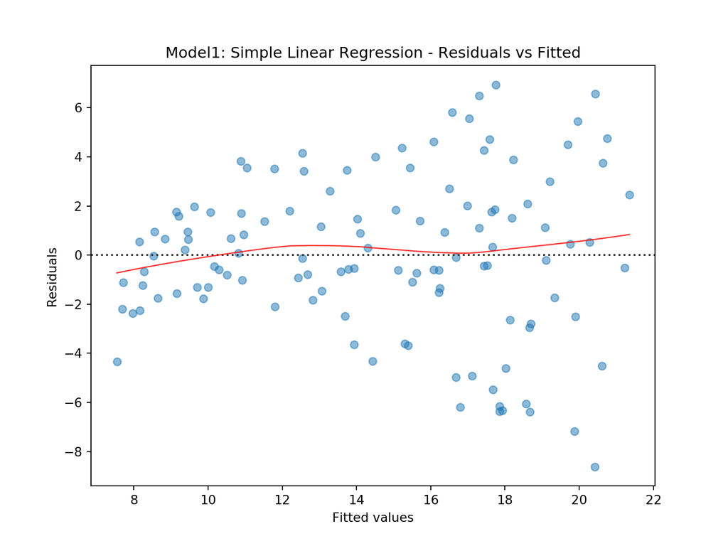

[figure not shown]

[figure not shown]

```python
plot1 = sb.residplot(model1_fit.fittedvalues,
                     train_data.columns[3],
                     data = train_data,
                     lowess = True,
                     scatter_kws = {'alpha': 0.5},
                     line_kws = {'color': 'red', 'lw': 1, 'alpha': 0.8})

plot1.set_title('Model1: Simple Linear Regression - Residuals vs Fitted')
plot1.set_xlabel('Fitted values')
plot1.set_ylabel('Residuals');

plt.show(plot1)
```

## Checking that the residuals are normally distributed

- This is another assumption that is often checked via graphical methods
- We are looking to verify that the residuals are normally distributed by plotting them on what is know as a quantile-quantile plot (or QQ plot)

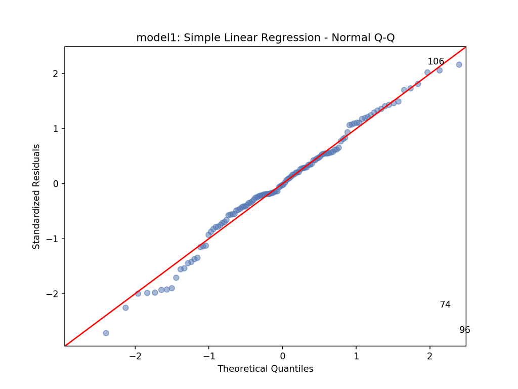

[figure not shown]

[figure not shown]

```python
from statsmodels.graphics.gofplots import ProbPlot

model1_norm_residuals = model1_fit.get_influence().resid_studentized_internal

QQ = ProbPlot(model1_norm_residuals)

plot_lm1 = QQ.qqplot(line = '45',
                     alpha = 0.5,
                     color = '#4C72B0',
                     lw = 1)

plot_lm1.axes[0].set_title('model1: Simple Linear Regression - Normal Q-Q')
plot_lm1.axes[0].set_xlabel('Theoretical Quantiles')
plot_lm1.axes[0].set_ylabel('Standardized Residuals');

# annotations
abs_norm_resid = np.flip(np.argsort(np.abs(model1_norm_residuals)), 0)
abs_norm_resid_top_3 = abs_norm_resid[:3]

for r, i in enumerate(abs_norm_resid_top_3):
    plot_lm1.axes[0].annotate(i,
                               xy=(np.flip(QQ.theoretical_quantiles, 0)[r],
                                   model1_norm_residuals[i]));
plt.show(plot_lm1)
```

# Making Predictions

## Using `model1` to predict results for new inputs

```python
X1_new = test_data[{"TV"}]
X1_new = sm.add_constant(X1_new)

# make the predictions by the model
test_data["predictions1"] = model1_fit.predict(X1_new)

test_data
```

```
        TV  radio  newspaper  sales       rt  predictions1
2     17.2   45.9       69.3    9.3   789.48      8.160875
4    180.8   10.8       58.4   12.9  1952.64     15.890763
5      8.7   48.9       75.0    7.2   425.43      7.759261
7    120.2   19.6       11.6   13.2  2355.92     13.027492
8      8.6    2.1        1.0    4.8    18.06      7.754536
..     ...    ...        ...    ...      ...           ...
188  286.0   13.9        3.7   15.9  3975.40     20.861328
189   18.7   12.1       23.4    6.7   226.27      8.231748
194  149.7   35.6        6.0   17.3  5329.32     14.421329
197  177.0    9.3        6.4   12.8  1646.10     15.711218
199  232.1    8.6        8.7   13.4  1996.06     18.314622

[80 rows x 6 columns]
```

## Using `model2` to predict results for new inputs

```python
X2_new = test_data[{"TV","newspaper","radio"}]
X2_new = sm.add_constant(X2_new)

# make the predictions by the model
test_data["predictions2"] = model2_fit.predict(X2_new)

test_data
```

```
        TV  radio  newspaper  sales       rt  predictions1  predictions2
2     17.2   45.9       69.3    9.3   789.48      8.160875     12.649642
4    180.8   10.8       58.4   12.9  1952.64     15.890763     12.921887
5      8.7   48.9       75.0    7.2   425.43      7.759261     12.852842
7    120.2   19.6       11.6   13.2  2355.92     13.027492     12.186102
8      8.6    2.1        1.0    4.8    18.06      7.754536      3.635006
..     ...    ...        ...    ...      ...           ...           ...
188  286.0   13.9        3.7   15.9  3975.40     20.861328     18.534532
189   18.7   12.1       23.4    6.7   226.27      8.231748      6.030390
194  149.7   35.6        6.0   17.3  5329.32     14.421329     16.800408
197  177.0    9.3        6.4   12.8  1646.10     15.711218     12.671101
199  232.1    8.6        8.7   13.4  1996.06     18.314622     15.002765

[80 rows x 7 columns]
```

## Using `model3` to predict results for new inputs

```python
X3_new = test_data[{"TV","radio","rt"}]
X3_new = sm.add_constant(X3_new)

# make the predictions by the model
test_data["predictions3"] = model3_fit.predict(X3_new)

test_data
```

```
        TV  radio  newspaper  ...  predictions1  predictions2  predictions3
2     17.2   45.9       69.3  ...      8.160875     12.649642      9.911902
4    180.8   10.8       58.4  ...     15.890763     12.921887     12.634462
5      8.7   48.9       75.0  ...      7.759261     12.852842      9.534629
7    120.2   19.6       11.6  ...     13.027492     12.186102     12.224859
8      8.6    2.1        1.0  ...      7.754536      3.635006      6.771984
..     ...    ...        ...  ...           ...           ...           ...
188  286.0   13.9        3.7  ...     20.861328     18.534532     16.921769
189   18.7   12.1       23.4  ...      8.231748      6.030390      7.687408
194  149.7   35.6        6.0  ...     14.421329     16.800408     16.531418
197  177.0    9.3        6.4  ...     15.711218     12.671101     12.182430
199  232.1    8.6        8.7  ...     18.314622     15.002765     13.620631

[80 rows x 8 columns]
```

## Predicted Residual Sum of Squares (PRESS)

```python
import pandas as pd
import numpy as np
import statsmodels.api as sm

data_url = "http://faculty.marshall.usc.edu/gareth-james/ISL/Advertising.csv"

df = pd.read_csv(data_url,
                 usecols = {'TV','newspaper','radio','sales'})

# add interaction term
df2["rt"] = df2["radio"] * df2["TV"]

df.head()
```

```
      TV  radio  newspaper  sales
0  230.1   37.8       69.2   22.1
1   44.5   39.3       45.1   10.4
2   17.2   45.9       69.3    9.3
3  151.5   41.3       58.5   18.5
4  180.8   10.8       58.4   12.9
```

```python
def PRESS(df, y_col, X_cols, add_const = True):
  y = df[y_col]
  X = df[X_cols]
  if add_const: X = sm.add_constant(X)
  press = 0.0

  for i in range(df.shape[0]):
    X_d = X.drop(index = i)
    y_d = y.drop(index = i)
    mod = sm.OLS(y_d, X_d)

    mod_fit = mod.fit()
    X_n = X[X_cols]
    if add_const: X_n = sm.add_constant(X_n)
    X_N = X_n.iloc[[i]]

    y_i_pred = mod_fit.predict(X_N).iloc[0]
    press = press + (y.iloc[i] - y_i_pred)**2

  return(press)
```

```python
#simple regression model
PRESS(df2, y_col="sales", X_cols={"TV"}, add_const=False )

#multiple regression model w/o interaction
```

```
4654.047299168079
```

```python
PRESS(df2,y_col="sales", X_cols={"TV","radio"})

#multiple regression model with interaction
```

```
582.1351590132707
```

```python
PRESS(df2,y_col="sales", X_cols={"TV","radio","rt"})
```

```
185.35335759039347
```